# Biostat M280 Homework 2

Due Feb 16 @ 11:59PM

Landi Luo

2/12/2018

## Q1

Read [Chapter 7](http://r4ds.had.co.nz/exploratory-data-analysis.html) (Exploratory Data Analysis) of *R for Data Science* and do exercises 7.3.4, 7.4.1, 7.5.1.1, 7.5.2.1, and 7.5.3.1.

### Exercise 7.3.4

1. Explore the distribution of each of the `x`, `y`, and `z` variables in `diamonds`. What do you learn? Think about a diamond and how you might decide which dimension is the length, width, and depth.

   ```r
   # load packages and datasets
   if (!"tidyverse" %in% rownames(installed.packages()))
     install.packages("tidyverse", repos = "http://cran.rstudio.com/")
   if (!"nycflights13" %in% rownames(installed.packages()))
     install.packages("nycflights13", repos = "http://cran.rstudio.com/")
   if (!"ggstance" %in% rownames(installed.packages()))
     install.packages("ggstance", repos = "http://cran.rstudio.com/")
   if (!"lvplot" %in% rownames(installed.packages()))
     install.packages("lvplot", repos = "http://cran.rstudio.com/")
   if (!"ggbeeswarm" %in% rownames(installed.packages()))
     install.packages("ggbeeswarm", repos = "http://cran.rstudio.com/")
   suppressMessages(library(tidyverse))
   suppressMessages(library(nycflights13))
   suppressMessages(library(ggstance))
   suppressMessages(library(lvplot))
   suppressMessages(library(ggbeeswarm))
   ```

   *The x variable has minimum value = 0 and maximum value = 10.74. The y variable has range 0 to 58.9. The z variable has range 0 to 31.8. When we look at the histograms of each variable, we can see that the distribution concentrates around 0 to 15, so I removed the outliers to better compare the variables. Thinking about the dimensions of a diamond, I would expect the length and width distributions to be approximately the same, and I would expect the depth to have smaller values in general. Comparing the three histograms, the x and y variables have similar distributions so I would guess that x and y are the length and width, and z is the depth. In addition, I plotted a scatterplot of y vs. x (in blue) and z vs. x (in pink). The scatterplot shows a strong linear correlation between x and y, and we can see the x and y have very similar values (intercept is approximately 0). Whereas the correlation between x and z is more scattered, and z tends to have smaller values than x. These observations confirm my conclusion.*

   ```r
   # explore range of x, y, and z
   count(diamonds, min(x), max(x))
   ```

   ```
   ## # A tibble: 1 x 3
   ##   `min(x)` `max(x)`     n
   ##      <dbl>    <dbl> <int>
   ## 1        0     10.7 53940
   ```

   ```r
   count(diamonds, min(y), max(y))
   ```

   ```
   ## # A tibble: 1 x 3
   ##   `min(y)` `max(y)`     n
   ##      <dbl>    <dbl> <int>
   ## 1        0     58.9 53940
   ```

   ```r
   count(diamonds, min(z), max(z))
   ```

   ```
   ## # A tibble: 1 x 3
   ##   `min(z)` `max(z)`     n
   ##      <dbl>    <dbl> <int>
   ## 1        0     31.8 53940
   ```

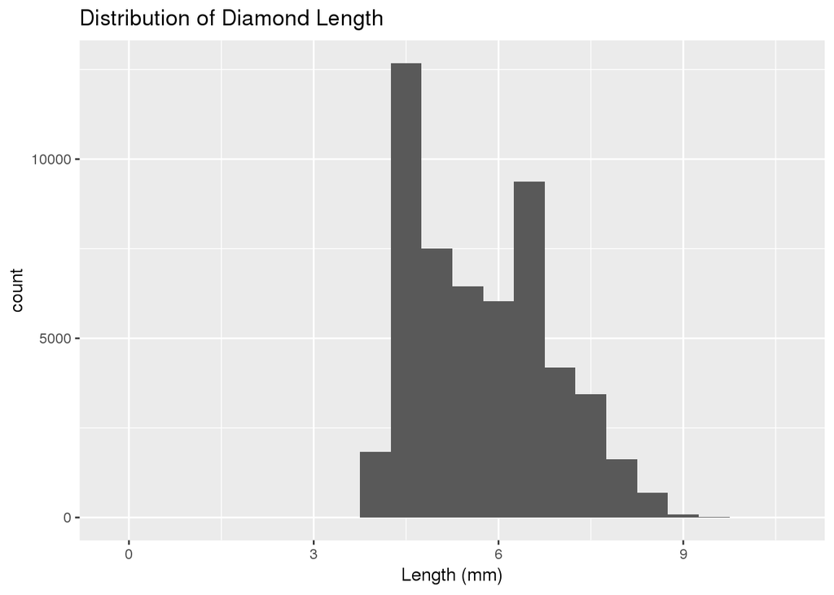

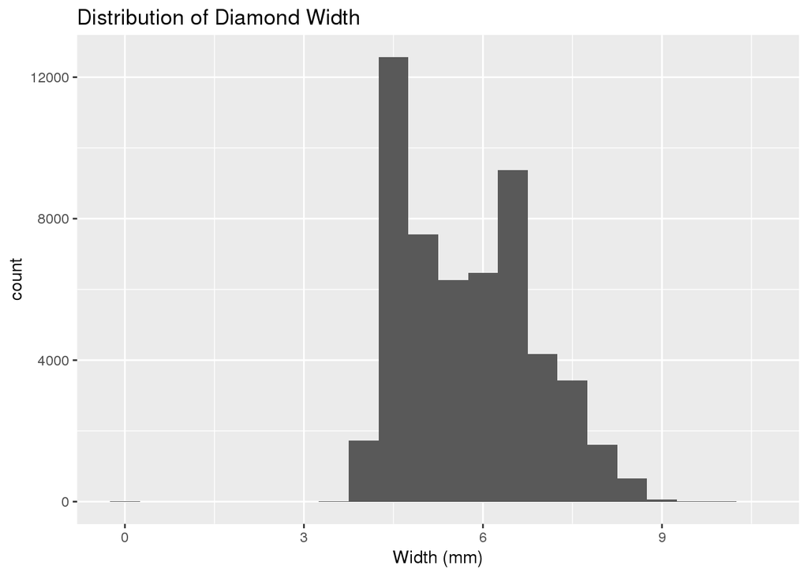

   ```r
   ggplot(data = diamonds2) +
     geom_histogram(mapping = aes(x = y), binwidth = 0.5) +
     labs(x = "Width (mm)", title = "Distribution of Diamond Width")
   ```

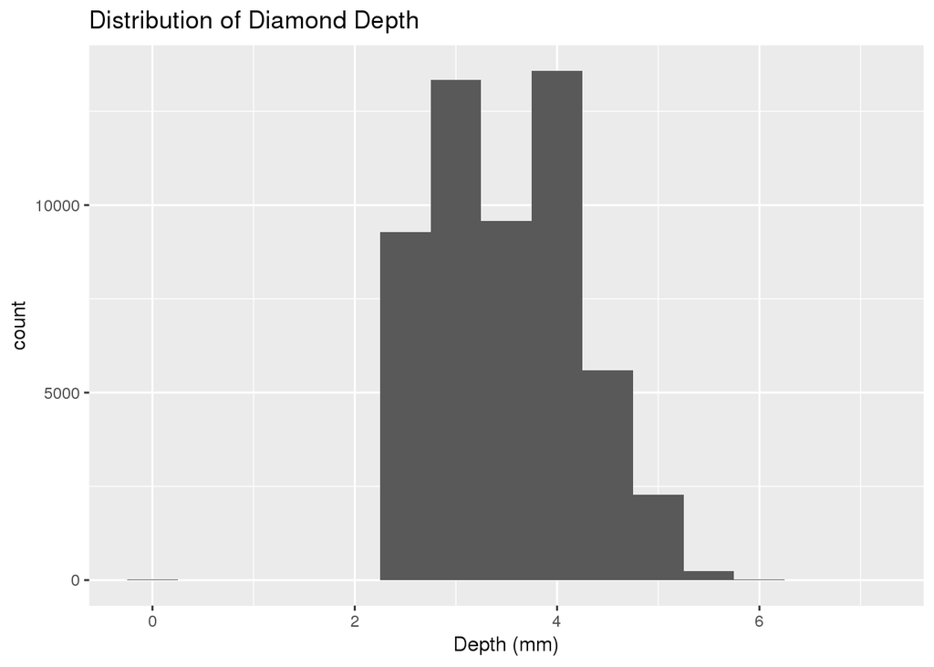

   ```r
   ggplot(data = diamonds2) +
     geom_histogram(mapping = aes(x = z), binwidth = 0.5) +
     labs(x = "Depth (mm)", title = "Distribution of Diamond Depth")
   ```

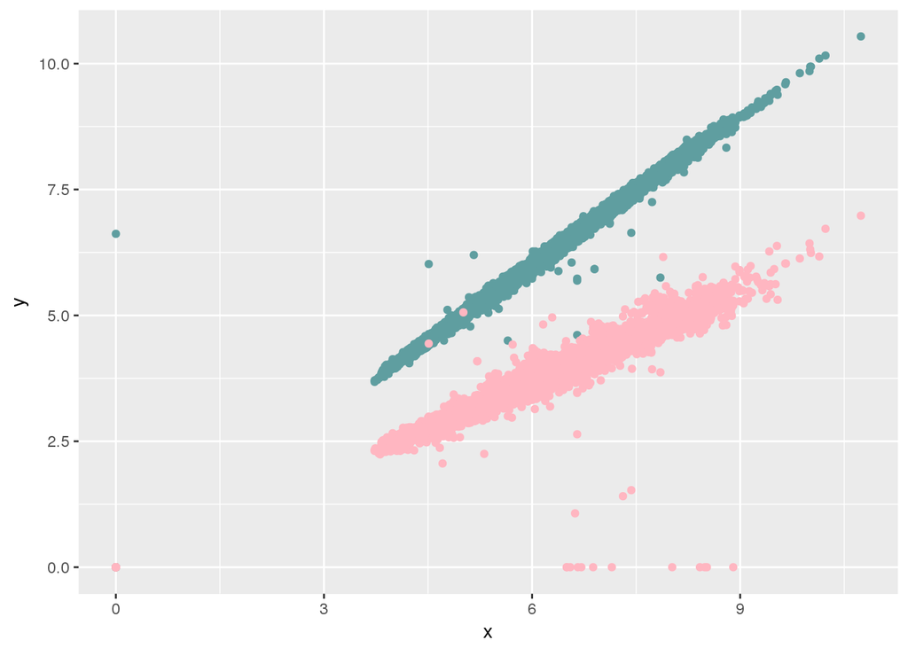

   ```r
   ggplot(data = diamonds2) +
     geom_point(mapping = aes(x = x, y = y), color = "cadetblue") +
     geom_point(mapping = aes(x = x, y = z), color = "lightpink")
   ```

   ```r
   count(diamonds, min(price), max(price))
   ```

   ```
   ## # A tibble: 1 x 3
   ##   `min(price)` `max(price)`     n
   ##          <dbl>        <dbl> <int>
   ## 1          326        18823 53940
   ```

   ```r
   count(diamonds, cut_width(price, 1000))
   ```

   ```
   ## # A tibble: 20 x 2
   ##    `cut_width(price, 1000)`     n
   ##    <fct>                    <int>
   ##  1 [-500,500]                1749
   ##  2 (500,1.5e+03]            18261
   ##  3 (1.5e+03,2.5e+03]         7532
   ##  4 (2.5e+03,3.5e+03]         4958
   ##  5 (3.5e+03,4.5e+03]         4535
   ##  6 (4.5e+03,5.5e+03]         3950
   ##  7 (5.5e+03,6.5e+03]         2627
   ##  8 (6.5e+03,7.5e+03]         1946
   ##  9 (7.5e+03,8.5e+03]         1395
   ## 10 (8.5e+03,9.5e+03]         1253
   ## 11 (9.5e+03,1.05e+04]        1000
   ## 12 (1.05e+04,1.15e+04]        899
   ## 13 (1.15e+04,1.25e+04]        721
   ## 14 (1.25e+04,1.35e+04]        655
   ## 15 (1.35e+04,1.45e+04]        576
   ## 16 (1.45e+04,1.55e+04]        482
   ## 17 (1.55e+04,1.65e+04]        471
   ## 18 (1.65e+04,1.75e+04]        437
   ## 19 (1.75e+04,1.85e+04]        391
   ## 20 (1.85e+04,1.95e+04]        102
   ```

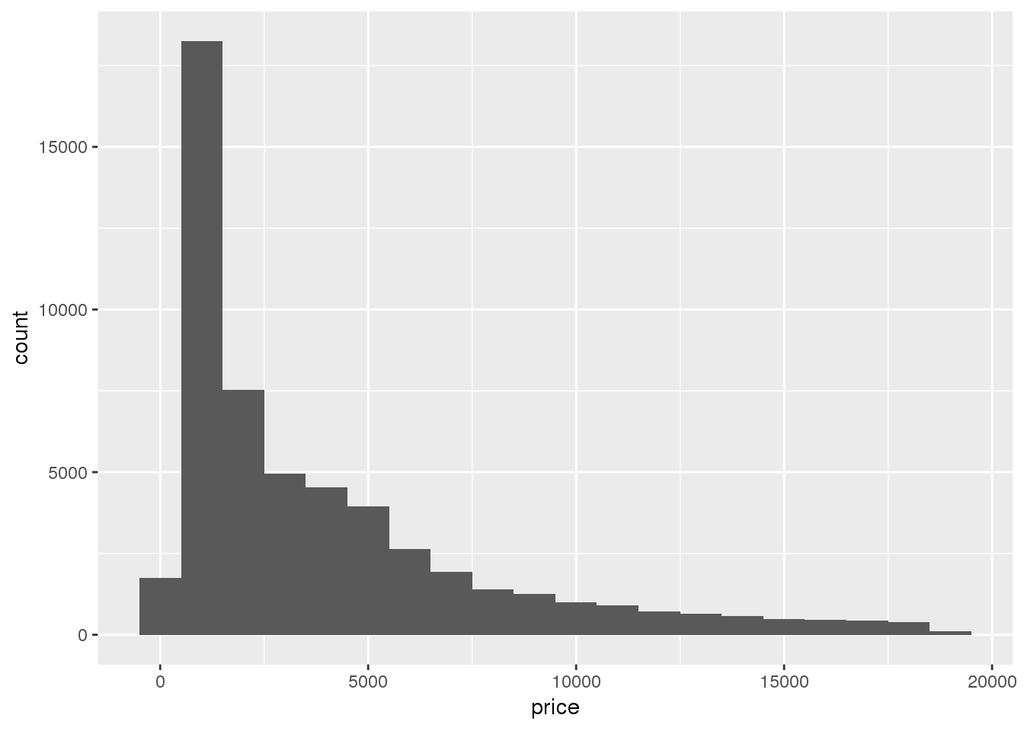

   ```r
   ggplot(data = diamonds) +
     geom_histogram(mapping = aes(x = price), binwidth = 1000)
   ```

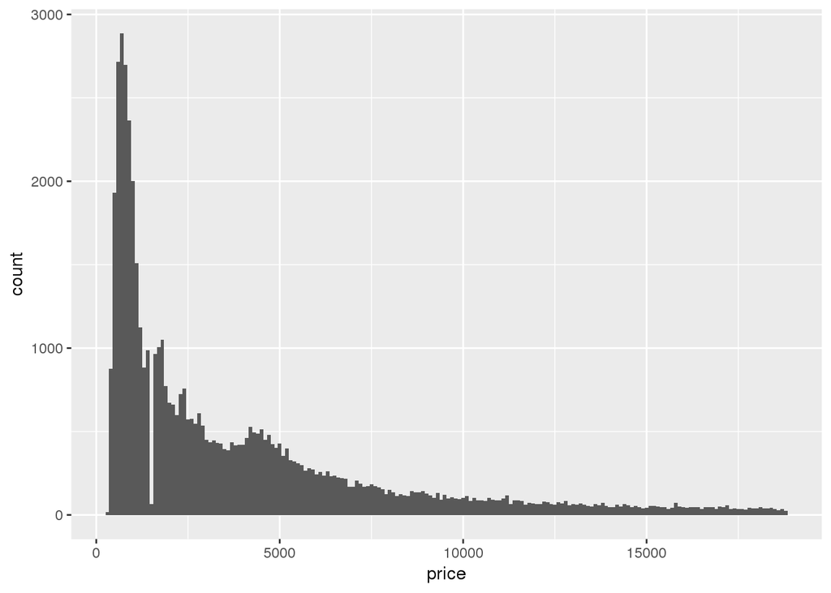

   ```r
   ggplot(data = diamonds) +
     geom_histogram(mapping = aes(x = price), binwidth = 100)
   ```

   ```r
   # explore unusual price gap
   diamonds %>%
     filter(price > 1000 & price < 2000) %>%
     count(cut_width(price, 100))
   ```

   ```
   ## # A tibble: 11 x 2
   ##    `cut_width(price, 100)`     n
   ##    <fct>                   <int>
   ##  1 [950,1.05e+03]            966
   ##  2 (1.05e+03,1.15e+03]      1510
   ##  3 (1.15e+03,1.25e+03]      1124
   ##  4 (1.25e+03,1.35e+03]       882
   ##  5 (1.35e+03,1.45e+03]       988
   ##  6 (1.45e+03,1.55e+03]        66
   ##  7 (1.55e+03,1.65e+03]       965
   ##  8 (1.65e+03,1.75e+03]      1005
   ##  9 (1.75e+03,1.85e+03]      1050
   ## 10 (1.85e+03,1.95e+03]       772
   ## 11 (1.95e+03,2.05e+03]       351
   ```

   ```r
   diamonds %>%
     filter(price > 1450 & price < 1550) %>%
     count(price)
   ```

   ```
   ## # A tibble: 8 x 2
   ##   price     n
   ##   <int> <int>
   ## 1  1451     4
   ## 2  1452     4
   ## 3  1453     5
   ## 4  1454     3
   ## 5  1546    21
   ## 6  1547     9
   ## 7  1548     7
   ## 8  1549     6
   ```

3. How many diamonds are 0.99 carat? How many are 1 carat? What do you think is the cause of the difference?  
   *23 diamonds are 0.99 carat, and 1558 diamonds are 1 carat. This may be because 1 carat diamonds can sell for a much higher price than 0.99 carat diamonds, because the whole number seems like a lot more.*

   ```r
   diamonds %>%
     filter(carat == 0.99 | carat == 1) %>%
     count(carat)
   ```

   ```
   ## # A tibble: 2 x 2
   ##   carat     n
   ##   <dbl> <int>
   ## 1 0.990    23
   ## 2 1.00   1558
   ```

4. Compare and contrast `coord_cartesian()` vs `xlim()` or `ylim()` when zooming in on a histogram. What happens if you leave `binwidth` unset? What happens if you try and zoom so only half a bar shows?  
   *When we leave `binwidth` unset, R generates an automatic binwidth along with a warning message. When we use `xlim()` and `ylim()` to zoom in on the data, R generates a warning message: “Removed 36329 rows containing non-finite values (stat_bin).” We can see that the histogram does not display bins past 4.9, whereas using `coord_cartesian()` keeps the values between 4.9 and 5.0. The histogram that uses `coord_cartesian()` is zoomed in so that only half a bar shows.*

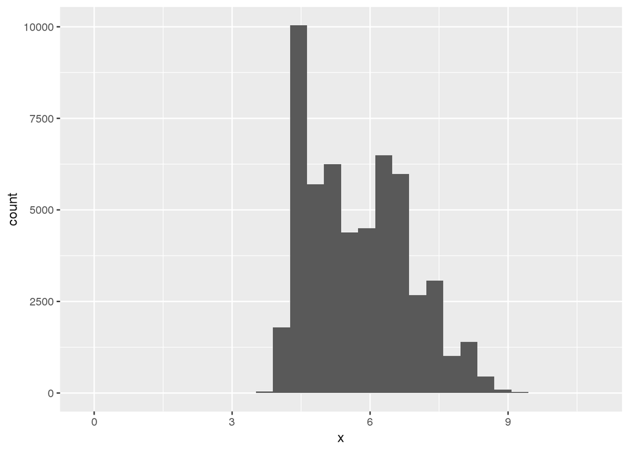

   ```r
   # leaving binwidth unset
   ggplot(data = diamonds) +
     geom_histogram(mapping = aes(x = x))
   ```

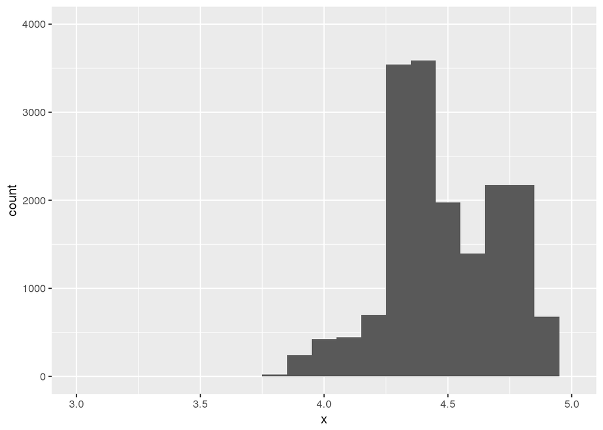

   ```r
   ggplot(data = diamonds) +
     geom_histogram(mapping = aes(x = x), binwidth = 0.1) +
     xlim(c(3, 5)) +
     ylim(c(0, 4000))
   ```

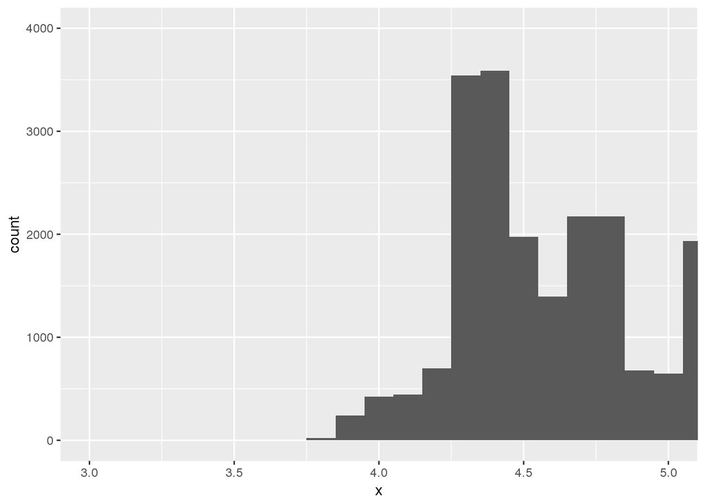

   ```r
   ggplot(data = diamonds) +
     geom_histogram(mapping = aes(x = x), binwidth = 0.1) +
     coord_cartesian(xlim = c(3, 5), ylim = c(0, 4000))
   ```

### Exercise 7.4.1

   ```
   ## Warning: Removed 8 rows containing non-finite values (stat_bin).
   ```

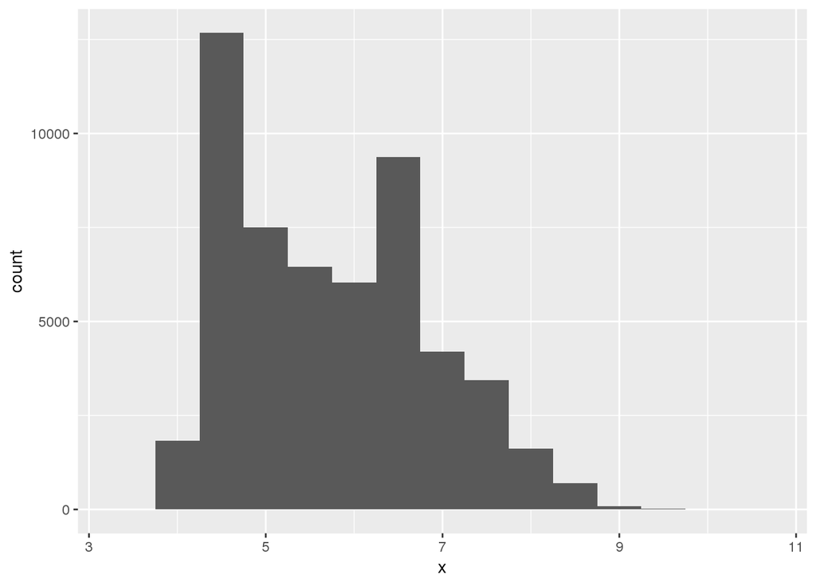

   ```r
   # explore missing values in a histogram
   diamonds3 <- diamonds %>%
     mutate(x = ifelse(x > 3 & x < 15, x, NA))
   ggplot(data = diamonds3) +
     geom_histogram(mapping = aes(x = x), binwidth = 0.5)
   ```

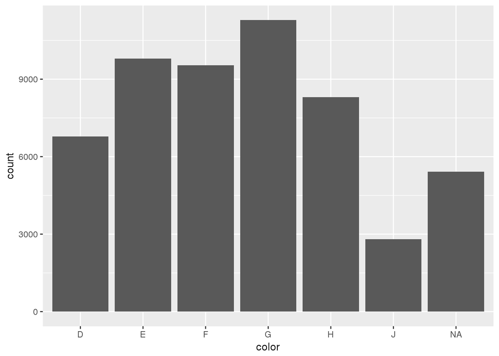

   ```r
   # explore missing values in a bar chart
   diamonds3 <- diamonds %>%
     mutate(color = ifelse(color == "I", NA_character_, as.character(color)))
   ggplot(data = diamonds3) +
     geom_bar(aes(x = color))
   ```

2. What does `na.rm = TRUE` do in `mean()` and `sum()`?  
   *The `na.rm = TRUE` removes NA values when carrying out the `mean()` and `sum()` calculations. Otherwise, the functions will return “NA” if there are NA values in the dataset.*

   ```r
   diamonds3 <- diamonds %>%
     mutate(x = ifelse(x > 3 & x < 15, x, NA))
   mean(diamonds3$x, na.rm = FALSE)
   ```

   ```
   ## [1] NA
   ```

   ```r
   mean(diamonds3$x, na.rm = TRUE)
   ```

   ```
   ## [1] 5.732007
   ```

   ```r
   sum(diamonds3$x, na.rm = FALSE)
   ```

   ```
   ## [1] NA
   ```

   ```r
   sum(diamonds3$x, na.rm = TRUE)
   ```

   ```
   ## [1] 309138.6
   ```

### Exercise 7.5.1.1

1. Use what you’ve learned to improve the visualisation of the departure times of cancelled vs. non-cancelled flights.  
   *I used boxplots to compare the scheduled departure times of cancelled vs. non-cancelled flights. The boxplots indicate that cancelled flights have a later scheduled departure time on average.*

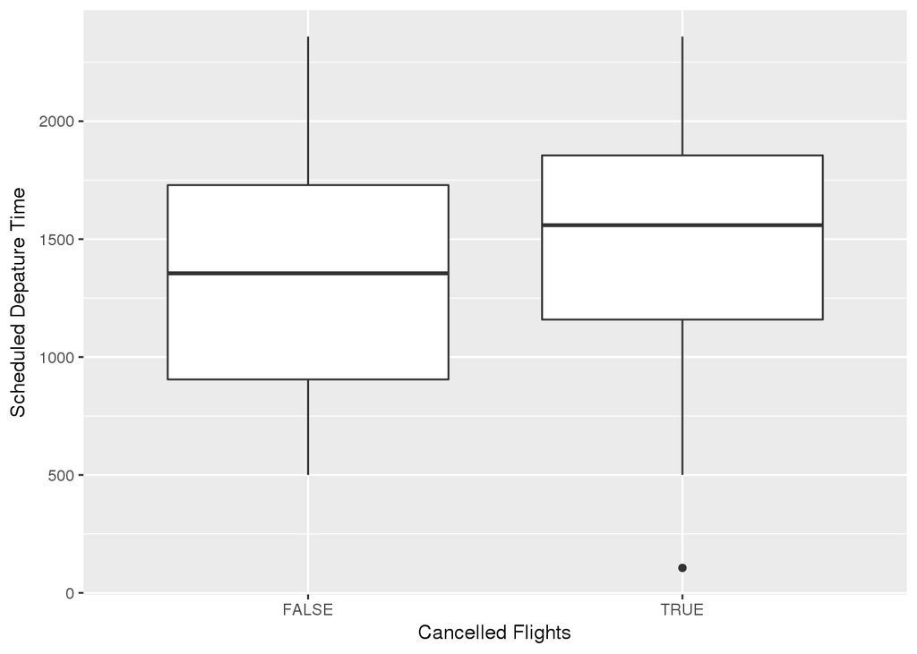

   ```r
   flights2 <- flights %>%
     mutate(cancelled = is.na(dep_time))
   ggplot(data = flights2) +
     geom_boxplot(aes(x = cancelled, y = sched_dep_time)) +
     labs(x = "Cancelled Flights", y = "Scheduled Depature Time")
   ```

2. What variable in the diamonds dataset is most important for predicting the price of a diamond? How is that variable correlated with cut? Why does the combination of those two relationships lead to lower quality diamonds being more expensive?  
   *The diamond’s carat is most important for predicting the price of a diamond. When we look at the scatterplot, there is a clear positive correlation between carat and price. Looking at the correlation between carat and cut, it appears that diamonds with “fair” cut have the highest carat, while the highest quality cut “ideal” has the lowest carat. This seems counterintuitive, as we would expect better quality diamonds to have higher carat. But the fact that “fair” cut diamonds have a higher carat does help explain the reason why lower quality diamonds are more expensive.*

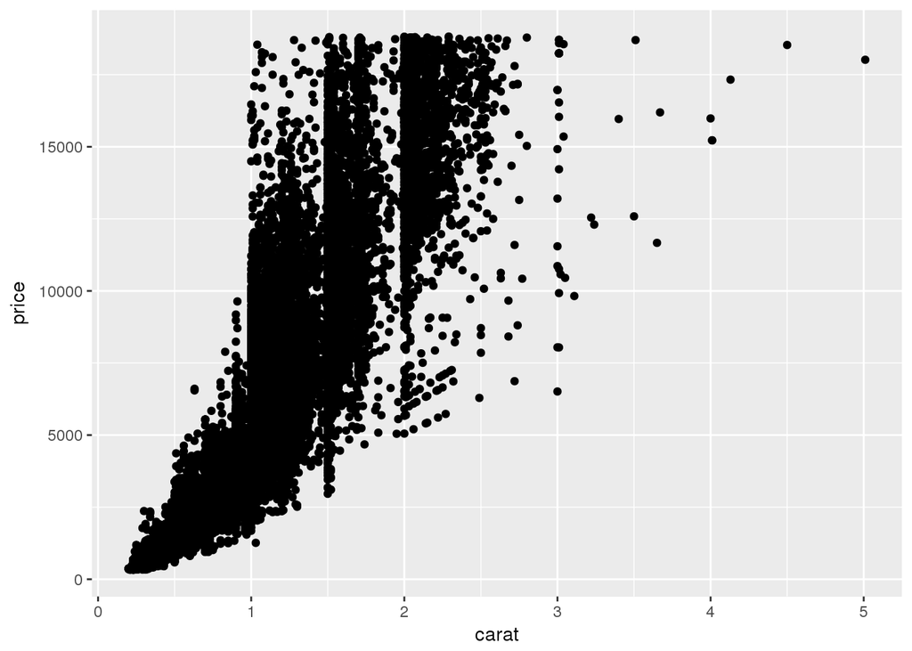

   ```r
   # explore relationships between price and other variables
   ggplot(data = diamonds) +
     geom_point(aes(x = carat, y = price))
   ```

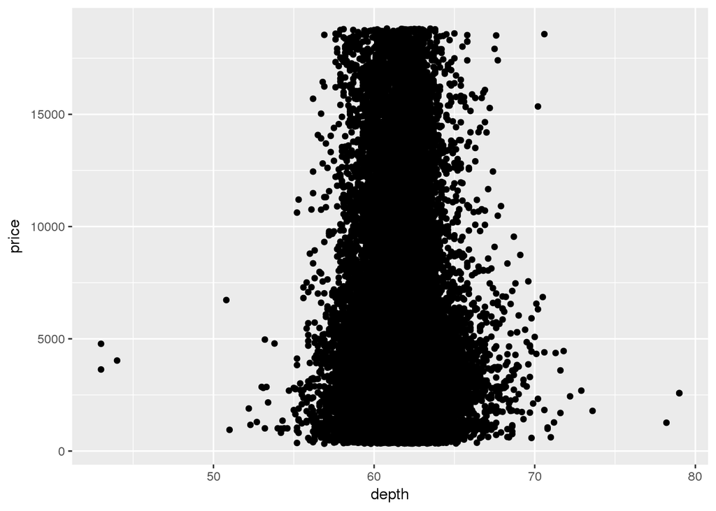

   ```r
   ggplot(data = diamonds) +
     geom_point(aes(x = depth, y = price))
   ```

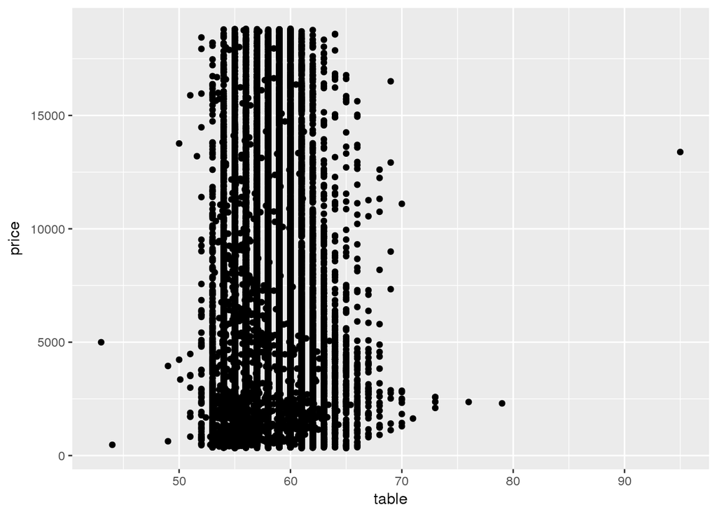

   ```r
   ggplot(data = diamonds) +
     geom_point(aes(x = table, y = price))
   ```

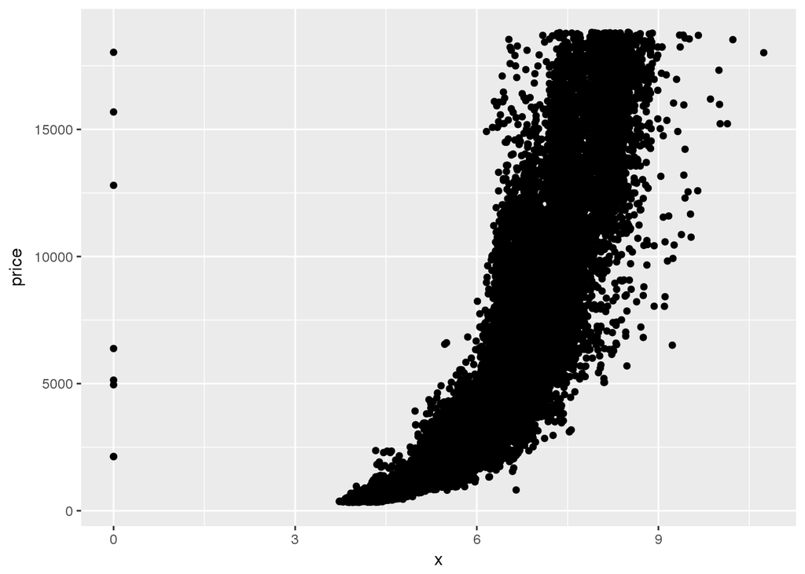

   ```r
   ggplot(data = diamonds) +
     geom_point(aes(x = x, y = price))
   ```

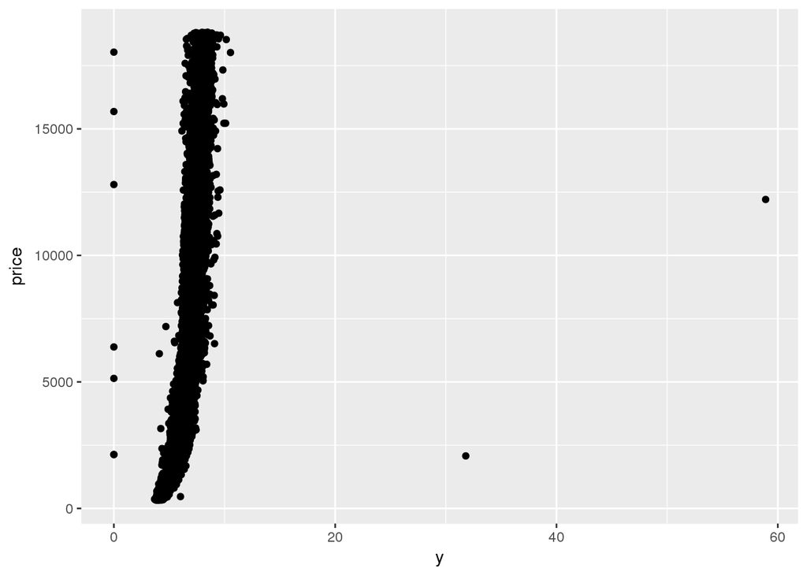

   ```r
   ggplot(data = diamonds) +
     geom_point(aes(x = y, y = price))
   ```

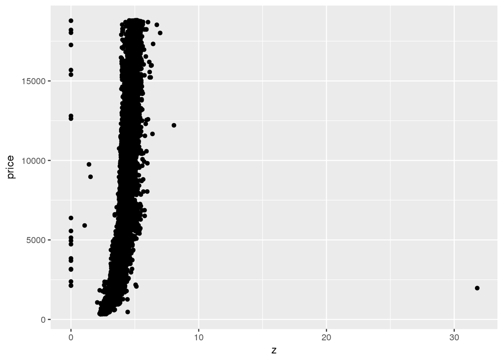

   ```r
   ggplot(data = diamonds) +
     geom_point(aes(x = z, y = price))
   ```

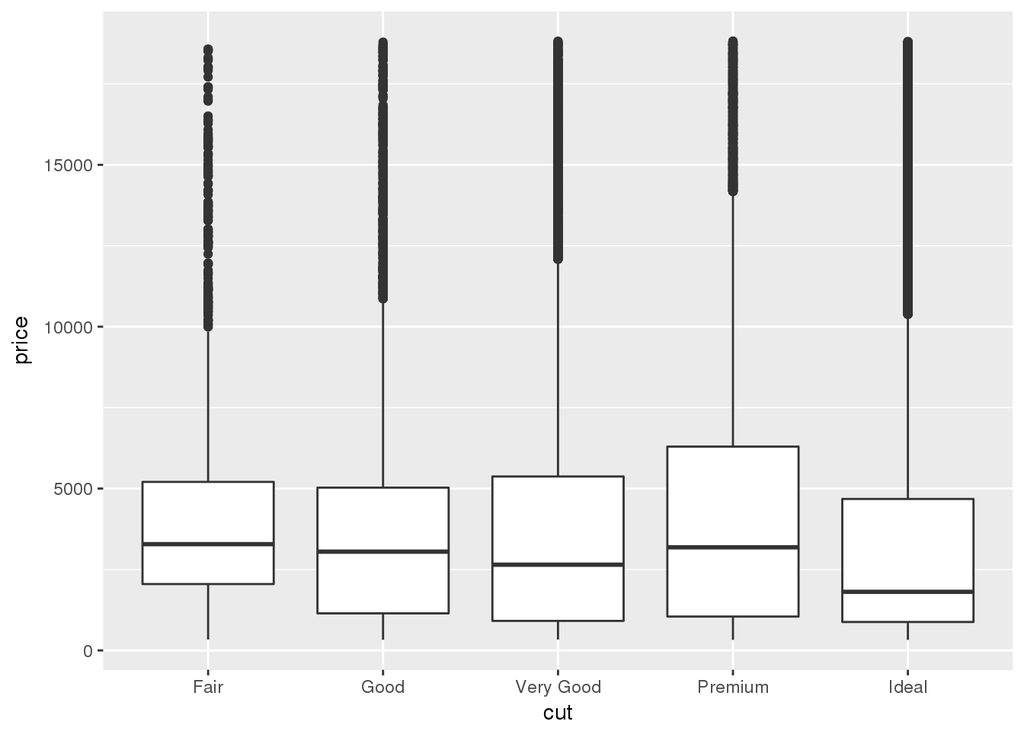

   ```r
   ggplot(data = diamonds) +
     geom_boxplot(aes(x = cut, y = price))
   ```

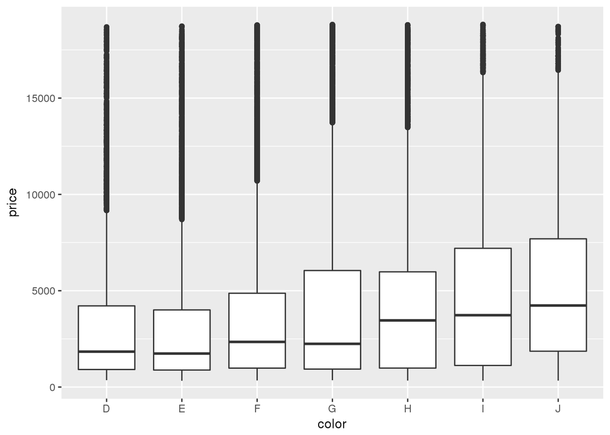

   ```r
   ggplot(data = diamonds) +
     geom_boxplot(aes(x = color, y = price))
   ```

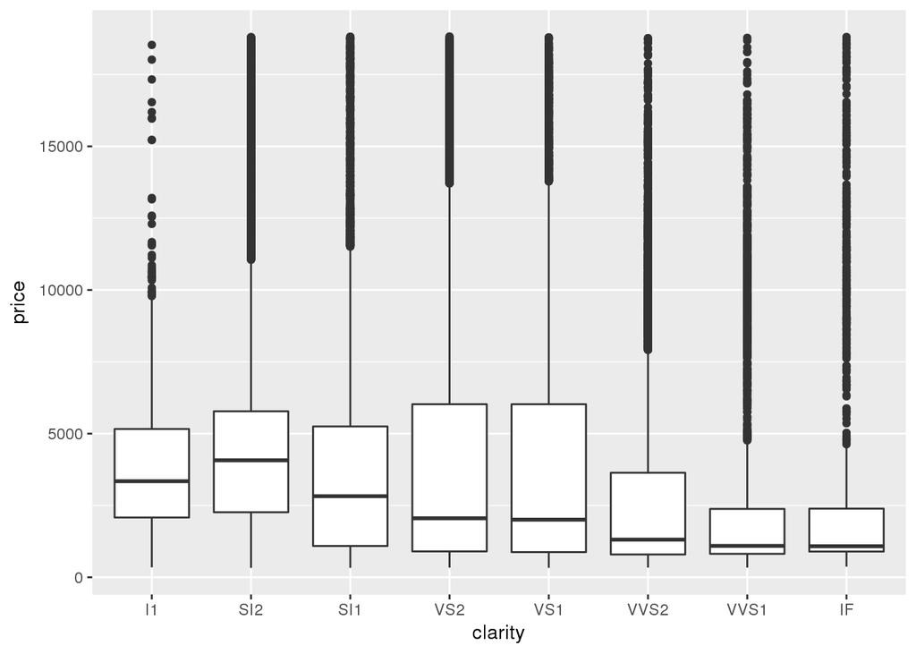

   ```r
   ggplot(data = diamonds) +
     geom_boxplot(aes(x = clarity, y = price))
   ```

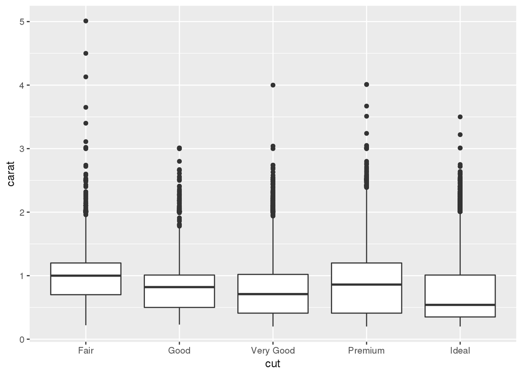

   ```r
   # relationship between carat and cut
   ggplot(data = diamonds) +
     geom_boxplot(aes(x = cut, y = carat))
   ```

3. Install the ggstance package, and create a horizontal boxplot. How does this compare to using `coord_flip()`?  
   *While the resulting boxplots appear to be the same, using the ggstance function is more intuitive as we can denote the x- and y-axes as they are, rather than flipping the labels and then using coord_flip().*

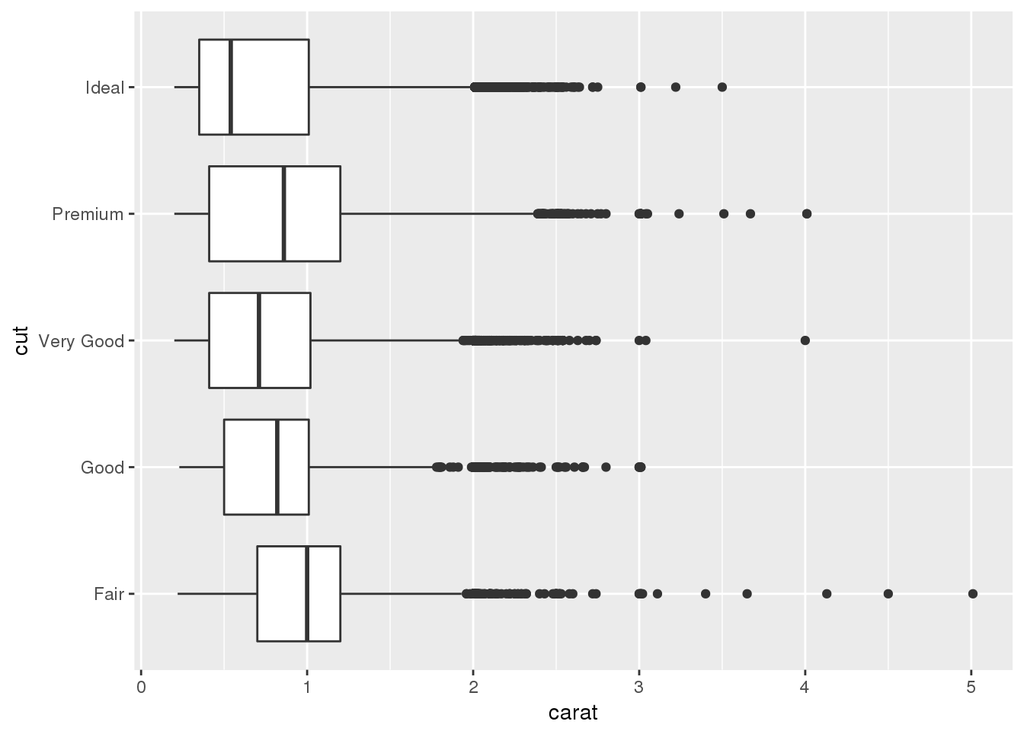

   ```r
   # using ggstance
   ggplot(data = diamonds) +
     geom_boxploth(aes(x = carat, y = cut))
   ```

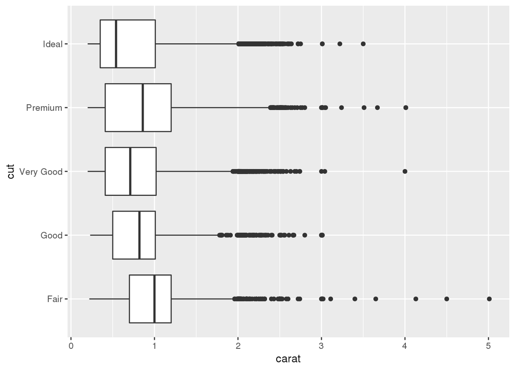

   ```r
   # using coord_flip()
   ggplot(data = diamonds) +
     geom_boxplot(aes(x = cut, y = carat)) +
     coord_flip()
   ```

4. One problem with boxplots is that they were developed in an era of much smaller datasets and tend to display a prohibitively large number of “outlying values”. One approach to remedy this problem is the letter value plot. Install the lvplot package, and try using `geom_lv()` to display the distribution of price vs cut. What do you learn? How do you interpret the plots?  
   *The letter value plot is more informative, as it doesn’t overemphasize outlier values. There are much fewer values that are considered outliers in the letter value plot compared to the conventional boxplot. While the boxplot showed that fair cut diamonds had the highest median prices, the letter value plot reveals that the ideal cut diamonds have a wider spread in their prices. As the diamond cut improves, there are more diamonds with higher prices. We could not observe this pattern using the boxplot. This is because the letter value plot includes those higher prices that the boxplot calculations leave out as outliers.*

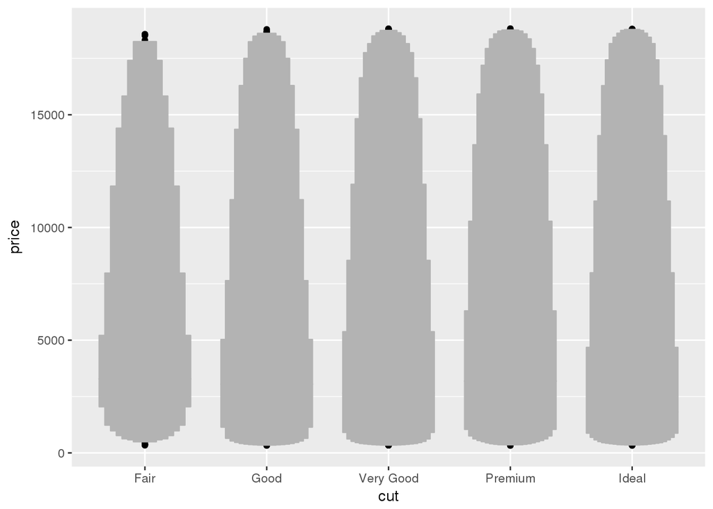

   ```r
   ggplot(diamonds) +
     geom_lv(aes(x = cut, y = price))
   ```

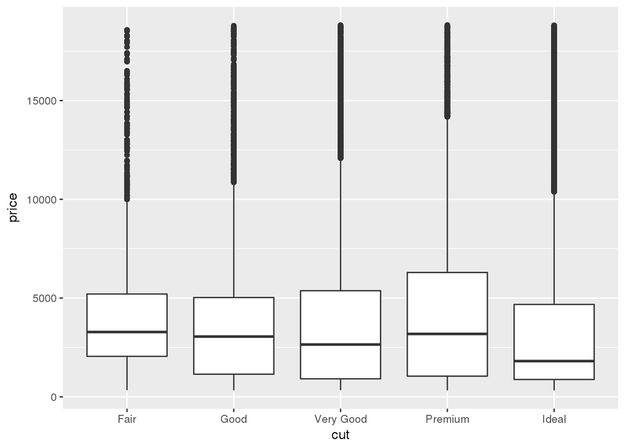

   ```r
   ggplot(diamonds) +
     geom_boxplot(aes(x = cut, y = price))
   ```

5. Compare and contrast `geom_violin()` with a facetted `geom_histogram()`, or a coloured `geom_freqpoly()`. What are the pros and cons of each method?  
   *`geom_violin()` is more useful for comparing the diamond prices among the different color categories. We can see that D colored diamonds have the lowest price, and we can see an increasing price trend from D to J. `geom_histogram()` and `geom_freqpoly()` are more useful for looking at the distribution of prices within each color category. We can see the peaks of each color, showing the most common price for that color.*

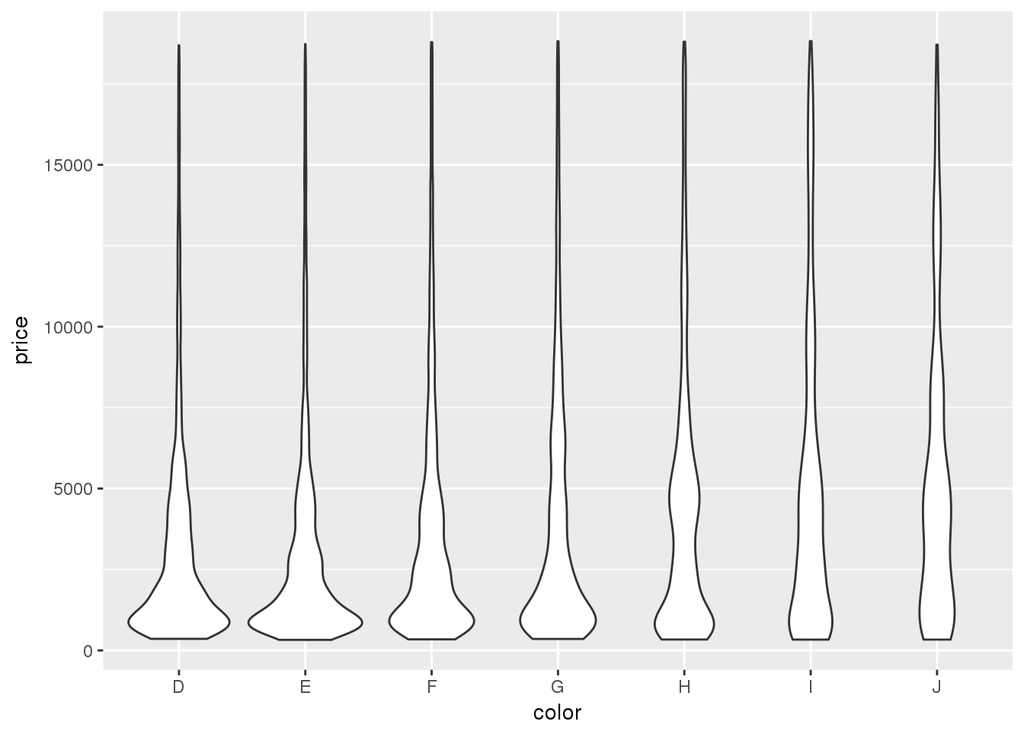

   ```r
   ggplot(data = diamonds) +
     geom_violin(aes(x = color, y = price))
   ```

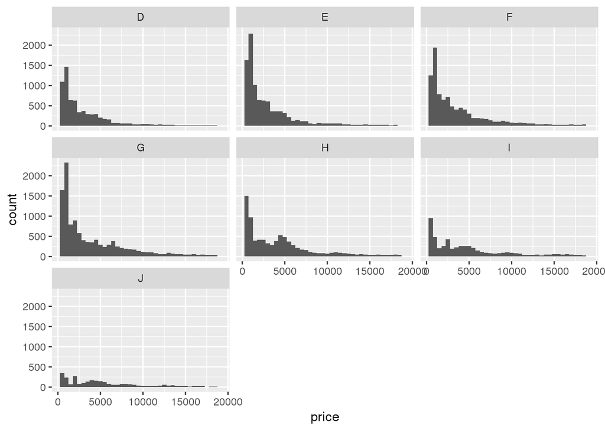

   ```r
   ggplot(data = diamonds) +
     geom_histogram(aes(x = price), binwidth = 500) +
     facet_wrap(~ color)
   ```

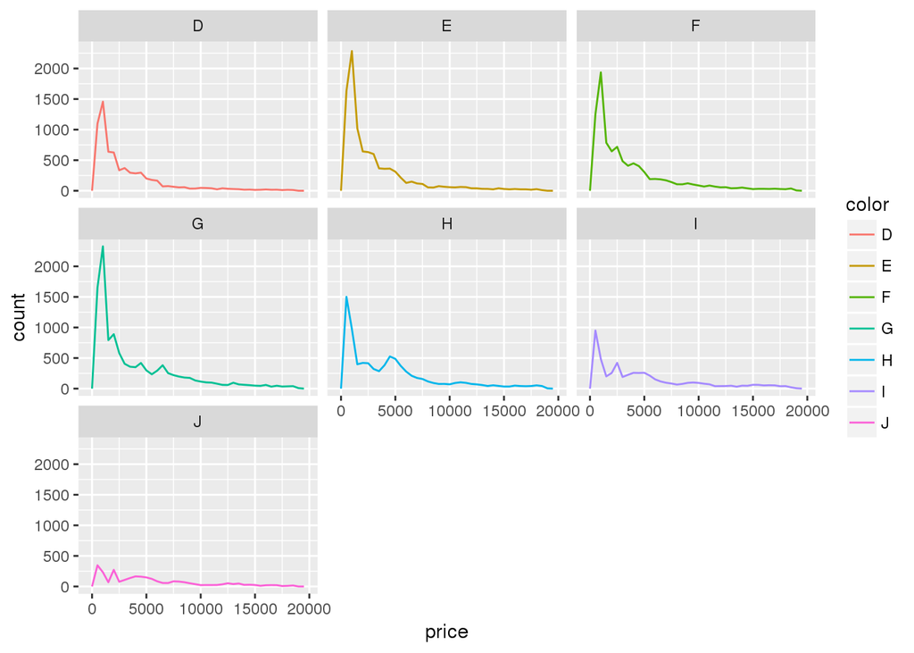

   ```r
   ggplot(data = diamonds) +
     geom_freqpoly(aes(x = price, color = color), binwidth = 500) +
     facet_wrap(~ color)
   ```

6. If you have a small dataset, it’s sometimes useful to use `geom_jitter()` to see the relationship between a continuous and categorical variable. The ggbeeswarm package provides a number of methods similar to `geom_jitter()`. List them and briefly describe what each one does.  
   *As the diamonds dataset is quite large, I chose to use the mpg dataset to explore the ggbeeswarm package. `geom_quasirandom()` jitters the points to reduce overplotting using the vipor package. `geom_beeswarm()` jitters the points to reduce overplotting using the beeswarm package. There appears to be slight differences in the way the points are jittered among the three methods. `geom_quasirandom()` and `geom_beeswarm()` seem to create violin plots and jitter the points.*

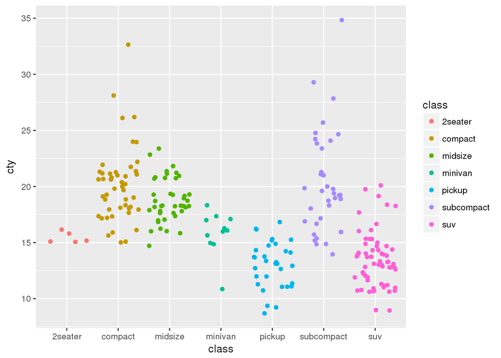

   ```r
   ggplot(data = mpg) +
     geom_jitter(aes(x = class, y = cty, color = class))
   ```

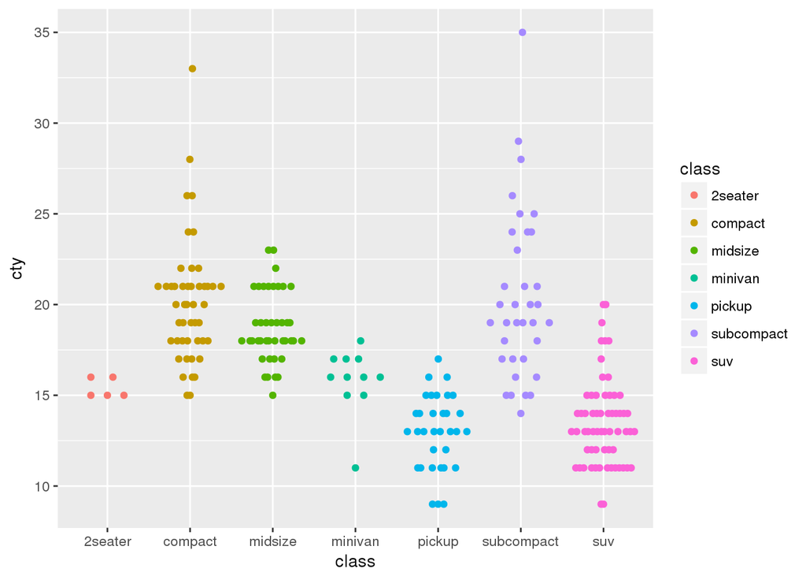

   ```r
   ggplot(data = mpg) +
     geom_quasirandom(aes(x = class, y = cty, color = class))
   ```

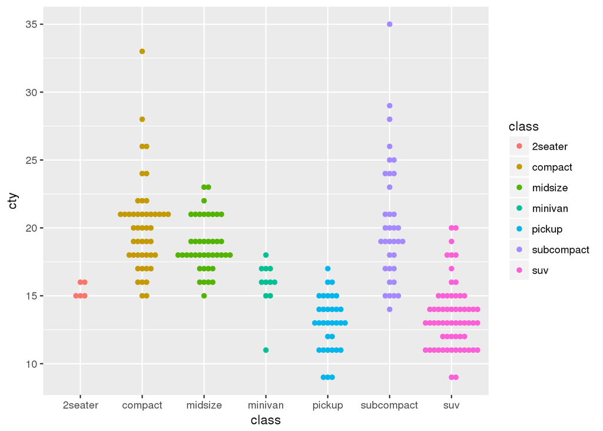

   ```r
   ggplot(data = mpg) +
     geom_beeswarm(aes(x = class, y = cty, color = class))
   ```